# **La API de Twitter**

Es una librería de Python que permite conectarse a Twitter para poder consultar sus datos. Para ello Twitter implementa unas APIs de servicios cuya documentación se puede encontrar en: https://developer.twitter.com/en/docs/twitter-api/api-reference-index

Twitter proporciona dos tipos de APIs:

**API Rest**

La API Rest permite buscar información histórica:

- Buscar Tweets
- Obtener los Timelines de usuarios
- Obtener información de cualquier usuario.
- Obtener los followers/followees de un usuario.

Existe un límite de peticiones al día de 100000 solicitudes de autenticación de usuario y de aplicación. Estos límites serán por aplicación y por endpoint, lo que significa que una sola aplicación de desarrollador puede realizar hasta 100000 llamadas a cada uno de los dos endpoints durante un solo período de 24 horas. La distribución de límites es la siguiente:

```
/statuses/mentions_timeline:
    75 peticiones/15 minutos (user-auth)
    100000 peticiones/24 horas (application level)

/statuses/user_timeline:
    900 requests/15 minutos (user-auth)
    1500 requests/15 minutos (app-auth)
    100000 requests/24 horas (application level)
```

**API Streaming**

La API Streamign permite buscar información en tiempo real.

**Requisitos**

Para poder usar las APIs de Twitter es necesario:

- Tener instalada la libreria Tweepy en el Jupyter Notebook:

  Para ello se utiliza "Anaconda Promt" introduciendo el siguiente comando:

  ```
            conda install -c conda-forge tweepy
  ```

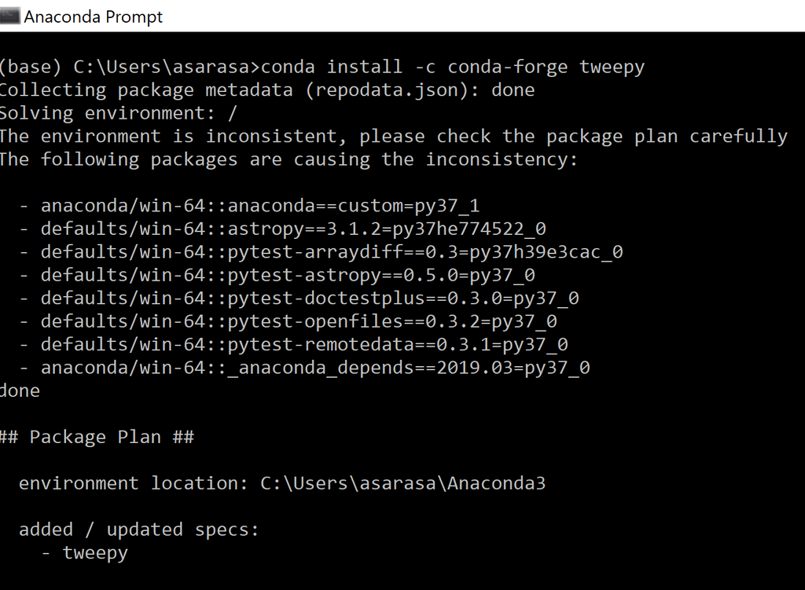

```python
from IPython.display import Image
Image(filename='Captura1.png')
```

- Tener cuenta desarrollador en Twitter: https://developer.twitter.com/en

**Autenticación**

Para poder usar las APIs de Twitter es necesario autenticarse:

- Admite la autenticación OAuth 1a (aplicación-usuario) y OAuth 2 (solo aplicación).
- La autenticación es manejada por la clase tweepy.AuthHandler.

**Autenticación OAuth 1a**

Para autenticarse hay que ir a la página del desarrollador de Twitter (https://developer.twitter.com/en) y registrar la aplicación que se vaya a realizar:

- Dentro de la cuenta de la página del desarrollador de Twitter, se selecciona la opción de Apps.
- En dicha página se utiliza la opción "Create an app"

[figure not shown]

```python
Image(filename='Captura2.png')
```

- A continuación aparece un formulario para poder registrar la aplicación, donde habrá que rellenar algunos datos tales como: el nombre de la aplicación, la dirección web, una descripción, y un pequeño texto donde se describe para que se utilizará la App

[figure not shown]

```python
Image(filename='Captura3.png')
```

- Finalmente se pulsa sobre el botón “Crear” y se acepta los términos de desarrollo de Twitter. A continuación, aparecerá listada la app creada. Si se pulsa en el enlace "Details" de la app creada se puede obtener información acerca de la misma.

[figure not shown]

```python
Image(filename='Captura4.png')
```

En particular interesa la pestaña "Keys and Tokens" donde aparecen 4 valores que se van a necesitar para poder comunicarse desde la aplicación con las APIs de Twitter:

- Consumer APIs Keys
- Access Tokens

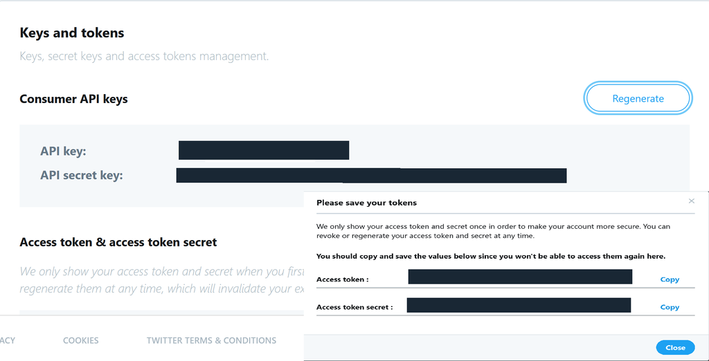

```python
Image(filename='Captura5.png')
```

Ahora ya se puede crear una pequeña aplicación en Python.

```python
import tweepy
from tweepy import OAuthHandler
consumer_key = "v0Nj5DixyXqkoJ4Z135T1pEKQ"
consumer_secret = "VgbVwoNx5h9IbrFZwrrTRPw1y7b9zPHVws6fcUWJpKbtI9kt6c"
access_token = "12400272-AFrcOZa0OKw3CsoqGBOh66WlR0ap4W0EHZo6anvtM"
access_token_secret = "APAttqclpN4AViyP2w6YOYOTA9t3g4LSbRWMLRpv3Ie5r"
# Se configura el acceso con las credenciales
auth = OAuthHandler(consumer_key, consumer_secret)
auth.set_access_token(access_token, access_token_secret)

#Se hace la conexion con el API
api = tweepy.API(auth)

texto = "Esto es un ejemplo de uso de Python con Twitter #tweepy y #python"
api.update_status(texto)
```

```
Status(_api=<tweepy.api.API object at 0x000001510A5CACF8>, _json={'created_at': 'Mon Nov 09 18:41:02 +0000 2020', 'id': 1325871034315272193, 'id_str': '1325871034315272193', 'text': 'Esto es un ejemplo de uso de Python con Twitter #tweepy y #python', 'truncated': False, 'entities': {'hashtags': [{'t…
```

Como resultado hay una entrada en mi cuenta de Twitter:

[figure not shown]

```python
Image(filename='Captura6.png')
```

Observaciones sobre el programa:

- Se han definido 4 variables con los valores que se han obtenido desde Twitter.
- Se ha creado un objeto de la clase OAuthHandler y se le han asignado las claves.
- Se asignan los token de acceso usando el objeto de OAuthHandler (la variable auth) y el método set_access_token()
- Se hace la conexión al API utilizando el objeto OAuthHandler y se almacena en una variable llamada “api”, la cuál es utilizada para acceder a todos los métodos del API.
- Se publica un tweet sencillo, para lo cual se asigna el texto a una variable. A continuación, usando la variable “api” y el método update_status(), el tweet se actualiza en el timeline de la cuenta.

**Autenticación OAuth 2**

Es un método de autenticación en el que una aplicación realiza solicitudes de API sin el contexto del usuario. Es decir accesos de lectura de información pública.

El proceso es similar al anterior, pero no es necesario el uso de los token de acceso. Por ejemplo se va a recuperar 10 tweets con información sobre "Trump"

```python
import tweepy
from tweepy import OAuthHandler
consumer_key = "v0Nj5DixyXqkoJ4Z135T1pEKQ"
consumer_secret = "VgbVwoNx5h9IbrFZwrrTRPw1y7b9zPHVws6fcUWJpKbtI9kt6c"
# Se configura el acceso con las credenciales
auth = OAuthHandler(consumer_key, consumer_secret)

#Se hace la conexion con el API
api = tweepy.API(auth)

for tweet in tweepy.Cursor(api.search, q='Trump').items(10):
    print(tweet.text)
```

```
Trump Friend of Jeffrey Epstein Epstein convicted Pedophile who was mysteriously found hanging in jail,murdered ??… https://t.co/Q5XiyIj70n
@BirkMatt There is nothing to proud of the Trump administration . He hardly ever opens his mouth out lying. Now tha… https://t.co/3tcLPMOWC7
@itstaylorsibits It said donald trump is 74 years old??
@toelvr4fun @DineshDSouza @survivinglife3 75,000,000 say Trump is bad.
@NathanWRobinson @DC_Draino They would of done that anyways but Biden rushing to claim himself the winner shows the… https://t.co/Z6HihspEhk
“This is the clearest indication yet that Trump understands he has lost the 2020 election to Joe Biden — even as th… https://t.co/ubl39ve4q5
RT @IoneSkye1: Let's just take a deep breath, let the Constitution work.  It is stronger than Trump, and will be here when he is gone in ju…
RT @cbozy: Wait, so Trump passed a bill in 2017 where ppl who makes under $75,000 will have their taxes raised in 2021 and every 2 years af…
@cj20007 @DougKass @tomkeene @jimcramer @carlquintanilla @SquawkCNBC It would be nice to see competency in an admin… https://t.co/aMH80Dou2n
@Timodc You literally- and I mean literally- cried for 4 years about Trump. Log off, Nancy, and find a real job. Yo… https://t.co/GApawCGE8F
```

En el programa se utiliza un objeto de tipo Cursor que permite iterar sobre los resultados de la consulta realizada:

- Se pasa al objeto el servicio que se quiere utilizar, y seguido los parámetros que requiera el servicio que se vaya a usar. En el ejemplo se va a usar el método de buscar y le pasamos como parámetro, la palabra clave que se está buscando, en este caso "Trump".
- Se pueden invocar métodos para limitar los resultados: items() y pages(). Con items() se limita el número de resultados recuperados y con pages() se limita el número de páginas de resultados recuperados.

```python
import tweepy
from tweepy import OAuthHandler
consumer_key = "v0Nj5DixyXqkoJ4Z135T1pEKQ"
consumer_secret = "VgbVwoNx5h9IbrFZwrrTRPw1y7b9zPHVws6fcUWJpKbtI9kt6c"
# Se configura el acceso con las credenciales
auth = OAuthHandler(consumer_key, consumer_secret)

#Se hace la conexion con el API
api = tweepy.API(auth)

for page in tweepy.Cursor(api.search, q='Trump').pages(2):
    print(page)
```

```
[Status(_api=<tweepy.api.API object at 0x000001510A5F40F0>, _json={'created_at': 'Mon Nov 09 19:26:41 +0000 2020', 'id': 1325882519535947777, 'id_str': '1325882519535947777', 'text': 'RT @marceelias: If people thought we would be seeing a barrage of new lawsuits from Trump today, they were wrong or …
[Status(_api=<tweepy.api.API object at 0x000001510A5F40F0>, _json={'created_at': 'Mon Nov 09 19:26:40 +0000 2020', 'id': 1325882517606572034, 'id_str': '1325882517606572034', 'text': 'RT @EvanAKilgore: Donald Trump coming back and winning the election would be the most on brand 2020 thing to happen.…
```

Se pueden hacer otras operaciones tales como:

- Comentar un tweet usando el parámetro in_reply_to_status_id para lo cual se necesita conocer id del tweet que va a ser comentado

```python
import tweepy
from tweepy import OAuthHandler
consumer_key = "v0Nj5DixyXqkoJ4Z135T1pEKQ"
consumer_secret = "VgbVwoNx5h9IbrFZwrrTRPw1y7b9zPHVws6fcUWJpKbtI9kt6c"
access_token = "12400272-AFrcOZa0OKw3CsoqGBOh66WlR0ap4W0EHZo6anvtM"
access_token_secret = "APAttqclpN4AViyP2w6YOYOTA9t3g4LSbRWMLRpv3Ie5r"
# Se configura el acceso con las credenciales
auth = OAuthHandler(consumer_key, consumer_secret)
auth.set_access_token(access_token, access_token_secret)

#Se hace la conexion con el API
api = tweepy.API(auth)

#Comentario
api.update_status('Ejemplo de comentario', in_reply_to_status_id="1325871034315272193")
```

```
Status(_api=<tweepy.api.API object at 0x000001510A64E7B8>, _json={'created_at': 'Mon Nov 09 19:37:41 +0000 2020', 'id': 1325885288997117954, 'id_str': '1325885288997117954', 'text': 'Ejemplo de comentario', 'truncated': False, 'entities': {'hashtags': [], 'symbols': [], 'user_mentions': [], 'urls': …
```

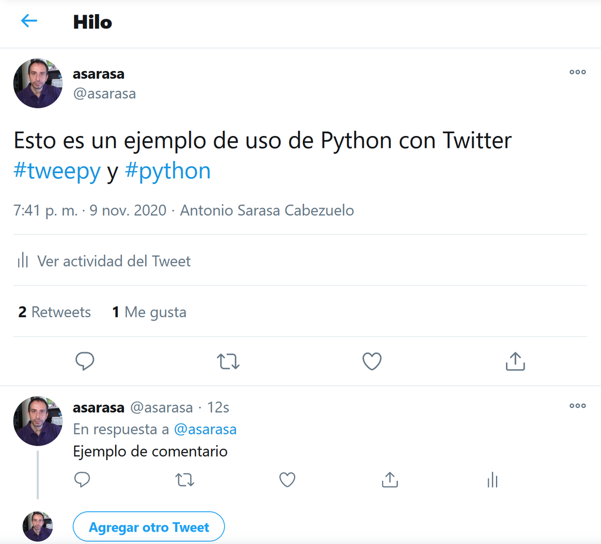

```python
Image(filename='Captura7.png')
```

- Subir una imagen y texto

```python
import tweepy
from tweepy import OAuthHandler
consumer_key = "v0Nj5DixyXqkoJ4Z135T1pEKQ"
consumer_secret = "VgbVwoNx5h9IbrFZwrrTRPw1y7b9zPHVws6fcUWJpKbtI9kt6c"
access_token = "12400272-AFrcOZa0OKw3CsoqGBOh66WlR0ap4W0EHZo6anvtM"
access_token_secret = "APAttqclpN4AViyP2w6YOYOTA9t3g4LSbRWMLRpv3Ie5r"
# Se configura el acceso con las credenciales
auth = OAuthHandler(consumer_key, consumer_secret)
auth.set_access_token(access_token, access_token_secret)

#Se hace la conexion con el API
api = tweepy.API(auth)

img = open("Gauss.jpg", 'rb')
id_imagen = api.media_upload(filename="Gauss.jpg",file=img)
print(id_imagen)

api.update_status("Foto de Gauss", media_ids=[id_imagen.media_id_string])
```

```
Media(_api=<tweepy.api.API object at 0x000001510A66BEF0>, media_id=1325887903285850112, media_id_string='1325887903285850112', size=5332, expires_after_secs=86400, image={'image_type': 'image/jpeg', 'w': 199, 'h': 253})
```

```
Status(_api=<tweepy.api.API object at 0x000001510A66BEF0>, _json={'created_at': 'Mon Nov 09 19:48:05 +0000 2020', 'id': 1325887905584312323, 'id_str': '1325887905584312323', 'text': 'Foto de Gauss https://t.co/ivPHWvjdlx', 'truncated': False, 'entities': {'hashtags': [], 'symbols': [], 'user_mention…
```

[figure not shown]

```python
Image(filename='Captura8.png')
```

Para subir la imagen se ha usado el método media_upload(), que lo que hace es cargar primero la imagen en twitter, el cual devuelve un ID de imagen. A continuación se usa el método update_status() y se agrega un parametro “media_ids” para agregar la imagen.

Se va a considerar dos ejemplos más. El primer ejemplo es una función que permite recuperar personas a las que se está siguiendo usando para ello el método api.friends_ids (devuelve un array que contiene los ID de los usuarios seguidos por el usuario especificado)

```python
def get_friends(api, screen_name, max_connections=0):
    friends = []
    max_connections_reached = False
    try:
        for friend_ids in tweepy.Cursor( api.friends_ids, screen_name=screen_name).pages():
            if max_connections and (len(friends) + len(friend_ids)) > max_connections:
                print('Conexiones máximas alcanzadas')
                friend_ids = friend_ids[:max_connections - len(friends)]
                max_connections_reached = True
            friends.extend(api.lookup_users(friend_ids))
            if max_connections_reached:
                break
    except Exception as e:
       print('Error fetching friends: {}'.format(e))
    return friends

import tweepy
from tweepy import OAuthHandler
consumer_key = "v0Nj5DixyXqkoJ4Z135T1pEKQ"
consumer_secret = "VgbVwoNx5h9IbrFZwrrTRPw1y7b9zPHVws6fcUWJpKbtI9kt6c"
# Se configura el acceso con las credenciales
auth = OAuthHandler(consumer_key, consumer_secret)

#Se hace la conexion con el API
api = tweepy.API(auth)
get_friends(api,"asarasa",3)
```

```
Conexiones máximas alcanzadas
```

```
[User(_api=<tweepy.api.API object at 0x000001510A6317B8>, _json={'id': 1235170397781450757, 'id_str': '1235170397781450757', 'name': 'Anmari05', 'screen_name': 'Anmari051', 'location': '', 'description': '🌹', 'url': None, 'entities': {'description': {'urls': []}}, 'protected': False, 'followers_coun…
 User(_api=<tweepy.api.API object at 0x000001510A6317B8>, _json={'id': 843855847914704897, 'id_str': '843855847914704897', 'name': 'eHealth Center UOC', 'screen_name': 'eHealthUOC', 'location': 'Barcelona, España', 'description': 'A center open to the world with the goal to #empower professionals & …
 User(_api=<tweepy.api.API object at 0x000001510A6317B8>, _json={'id': 477560179, 'id_str': '477560179', 'name': 'M. Antonia Huertas', 'screen_name': 'ma_huertas', 'location': 'Barcelona', 'description': 'lecturer, researcher and writer', 'url': None, 'entities': {'description': {'urls': []}}, 'prot…
```

El segundo ejemplo es una función que permite recuperar las personas que siguen a otra usando para ello el método api.followers_ids (devuelve un array que contiene los ID de los usuarios que siguen al usuario especificado)

```python
def get_friends(api, screen_name, max_connections=0):
    friends = []
    max_connections_reached = False
    try:
        for friend_ids in tweepy.Cursor( api.followers_ids, screen_name=screen_name).pages():
            if max_connections and (len(friends) + len(friend_ids)) > max_connections:
                print('Conexiones máximas alcanzadas')
                friend_ids = friend_ids[:max_connections - len(friends)]
                max_connections_reached = True
            friends.extend(api.lookup_users(friend_ids))
            if max_connections_reached:
                break
    except Exception as e:
       print('Error fetching friends: {}'.format(e))
    return friends

import tweepy
from tweepy import OAuthHandler
consumer_key = "v0Nj5DixyXqkoJ4Z135T1pEKQ"
consumer_secret = "VgbVwoNx5h9IbrFZwrrTRPw1y7b9zPHVws6fcUWJpKbtI9kt6c"
# Se configura el acceso con las credenciales
auth = OAuthHandler(consumer_key, consumer_secret)

#Se hace la conexion con el API
api = tweepy.API(auth)
get_friends(api,"asarasa",3)
```

```
Conexiones máximas alcanzadas
```

```
[User(_api=<tweepy.api.API object at 0x000001510A5FF6A0>, _json={'id': 1235170397781450757, 'id_str': '1235170397781450757', 'name': 'Anmari05', 'screen_name': 'Anmari051', 'location': '', 'description': '🌹', 'url': None, 'entities': {'description': {'urls': []}}, 'protected': False, 'followers_coun…
 User(_api=<tweepy.api.API object at 0x000001510A5FF6A0>, _json={'id': 44873371, 'id_str': '44873371', 'name': 'David Villaseca', 'screen_name': 'dvillaseca', 'location': 'Silicon Valley', 'description': '#Digital Business & Marketing expert | Board member @CaliforniaSpain | Global team @Oracle | Vi…
 User(_api=<tweepy.api.API object at 0x000001510A5FF6A0>, _json={'id': 89678123, 'id_str': '89678123', 'name': 'mhcris', 'screen_name': 'mhcris', 'location': '', 'description': '', 'url': None, 'entities': {'description': {'urls': []}}, 'protected': True, 'followers_count': 43, 'friends_count': 660,…
```

En la siguiente página, se pueden encontrar otras funciones similares ya implementadas que realizan operaciones útiles. Pero hay que tener cuidado porque hay erratas en el código: https://www.programcreek.com/python/example/76301/tweepy.Cursor

En los anteriores ejemplos se ha usado la API Rest, ahora se verá un ejemplo de uso de la API Streaming. Este API permite acceder a tweets en tiempo real. Para usarlo se siguen los pasos:

- Crear una clase que herede de StreamListener.
- Crear un objeto de tipo Stream usando la clase definida.
- Conectarse a la API usando el objeto Stream

```python
import tweepy
from tweepy import OAuthHandler

#Se define la nueva clase
class SimpleListener(tweepy.StreamListener):
    def on_status(self, status):
        #Código a ejecutar cada vez que la transmisión recibe un estado
        print(status.text)

    def on_direct_message(self, status):
        #Código para ejecutar cada vez que la transmisión recibe un mensaje directo
        print(status.text)

    def on_data(self, status):
        #Código para ejecutar cada vez que reciba algunos datos (mensaje directo, eliminar, actualización de perfil, estado, ...)
        print(status.text)

    def on_error(self, status_code):
        #Código para ejecutar cada vez que se recibe un error
        if status_code == 420:
            return False
        else:
            return True


from tweepy import OAuthHandler
consumer_key = "v0Nj5DixyXqkoJ4Z135T1pEKQ"
consumer_secret = "VgbVwoNx5h9IbrFZwrrTRPw1y7b9zPHVws6fcUWJpKbtI9kt6c"
# Se configura el acceso con las credenciales
auth = OAuthHandler(consumer_key, consumer_secret)
#Se hace la conexion con el API
api = tweepy.API(auth)

#Crear el objeto
tweepy_listener = SimpleListener()
tweepy_stream = tweepy.Stream(auth = api.auth, listener=tweepy_listener)
tweepy_stream.filter(track=['covid'])
```

Se va a realizar un último ejemplo donde se van a recuperar 30 tweets acerca de la palabra clave "Trump"

```python
import tweepy
import json
from tweepy import OAuthHandler
consumer_key = "v0Nj5DixyXqkoJ4Z135T1pEKQ"
consumer_secret = "VgbVwoNx5h9IbrFZwrrTRPw1y7b9zPHVws6fcUWJpKbtI9kt6c"
# Se configura el acceso con las credenciales
auth = OAuthHandler(consumer_key, consumer_secret)

#Se hace la conexion con el API
api = tweepy.API(auth)
max_tweets=30
query='Trump'
searched_tweets = [status._json for status in tweepy.Cursor(api.search,  q=query).items(max_tweets)]
json_strings = [json.dumps(json_obj) for json_obj in searched_tweets]
```

En la variable searched_tweets se encuentran una lista de los tweets como objetos JSON mientras que en json_strings existe una lista de los tweets en forma de cadena.

```python
searched_tweets
```

[output not shown]

[output cut: 3652 more lines]

[output not shown]

```python
json_strings
```

[output not shown]

[output cut: 17 more lines]

Se van a ver a continuación un par de ejemplos de procesamiento sobre los tweets recuperados. En el primero se encuentra la frecuencia de aparición de las diferentes palabras que aparecen en los tweets.

```python
def frequency(tweets):
    frequen={}
    for tweet in tweets:
        if "text" in tweet.keys():
            frequen=obtener(tweet,frequen)
    total=0
    terminos=frequen.keys()
    for termino in terminos:
        total=total+frequen[termino]
    for termino in terminos:
        print (termino," ",float(frequen[termino])/float(total))

def obtener(tweet,frequen):
    texto=tweet["text"]
    texto=texto.lower()
    texto=texto.encode('utf-8')
    frase=texto.split()
    terminos=dict.fromkeys(frase).keys()
    for termino in terminos:
        repeticiones=frase.count(termino)
        if termino in frequen.keys():
            frequen[termino]=frequen[termino]+repeticiones
        else:
            frequen[termino]=repeticiones
    return frequen

frequency(searched_tweets)
```

```
b'@gugachacra'   0.0017761989342806395
b'at\xc3\xa9'   0.0017761989342806395
b'trump'   0.03197158081705151
b'ser'   0.0017761989342806395
b'eleito'   0.0017761989342806395
b'pela'   0.0017761989342806395
b'justi\xc3\xa7a'   0.0017761989342806395
b'e'   0.0017761989342806395
b'escancarar'   0.0017761989342806395
b'a'   0.02664298401420959
b'fraude'   0.0017761989342806395
b'democrata.'   0.0017761989342806395
b'rt'   0.03019538188277087
b'@stuartpstevens:'   0.0017761989342806395
b'if'   0.0017761989342806395
b'will'   0.0053285968028419185
b'not'   0.014209591474245116
b'release'   0.0017761989342806395
b'legal'   0.0053285968028419185
b'transition'   0.0017761989342806395
b'funds,'   0.0017761989342806395
b'there'   0.0017761989342806395
b'is'   0.015985790408525755
b'no'   0.0053285968028419185
b'reason'   0.003552397868561279
b'for'   0.0053285968028419185
b'the'   0.03374777975133215
b'house'   0.0017761989342806395
b'to'   0.010657193605683837
b'approve'   0.0017761989342806395
b'post-presidency'   0.0017761989342806395
b'funds'   0.0017761989342806395
b'for\xe2\x80\xa6'   0.003552397868561279
b'@runroc:'   0.0017761989342806395
b'na'   0.003552397868561279
b'1a'   0.0017761989342806395
b'vaga,'   0.003552397868561279
b'o'   0.003552397868561279
b'm\xc3\xa9rito'   0.0017761989342806395
b'foi'   0.0017761989342806395
```

[output cut: 330 more lines]

```
b'haha!!!'   0.0017761989342806395
b'didn\xe2\x80\x99t'   0.0017761989342806395
b'want'   0.0017761989342806395
b'grifter'   0.0017761989342806395
b'attach'   0.0017761989342806395
b'himself'   0.0017761989342806395
b'lol'   0.0017761989342806395
b'running'   0.0017761989342806395
b'fight'   0.0017761989342806395
b'although'   0.0017761989342806395
b'he'   0.0017761989342806395
b'lawyer,'   0.0017761989342806395
b'has'   0.0017761989342806395
b'tested'   0.0017761989342806395
b'positive'   0.0017761989342806395
```

En el siguiente se encuentra los 10 hashtags más utilizados.

```python
def frequency(tweets):
    frequen={}
    for tweet in tweets:
        if "entities" in tweet.keys():
            hashtags=tweet["entities"]["hashtags"]
            if len(hashtags)>0:
                frequen=obtener(hashtags,frequen)
    frecuencias=list(frequen.items())
    frecuencias.sort(key=lambda x: x[1])
    frecuencias.reverse()
    i=0
    while i<10 and i<len(frecuencias):
        print (frecuencias[i][0]," ",frecuencias[i][1])
        i=i+1

def obtener(hashtags,frequen):
    i=0
    while i<len(hashtags):
        hashtag=hashtags[i]["text"]
        hashtag=hashtag.lower()
        hashtag=hashtag.encode('utf-8')
        if hashtag in frequen.keys():
            frequen[hashtag]=frequen[hashtag]+1
        else:
            frequen[hashtag]=1
        i=i+1
    return frequen

frequency(searched_tweets)
```

```
b'usa'   2
b'ditism'   1
b'9nov'   1
b'trump'   1
```

# **API REST**

La API de Twitter representa un caso de extremo en cuanto a su detalle y elaboración. Sin embargo, hay otros lugares que ofrece APIs basadas en el protocolo API-REST que define un método sencillo de enviar y recibir datos usando formatos tales como XML o JSON bajo el protocolo HTTP. En este sencillo para manipular la información se utiliza un conjunto muy pequeño de funciones: GET, POST, PUT y DELETE.

Se va a ver un ejemplo de API-REST en la que se usará la función GET para recuperar recursos que tienen asociado un identificador único en forma de URI. La URI está formada por la dirección del recurso y un diccionario con las opciones de búsqueda con claves que representan los parámetros debúsqueda y los valores que deben tomar.

El ejemplo que se va a usar un portal de datos abiertos sobre películas y series denominado OMDb API que se encuentra en:

http://www.omdbapi.com/

Para usarla hay que obtener una clave de uso en:

http://www.omdbapi.com/apikey.aspx

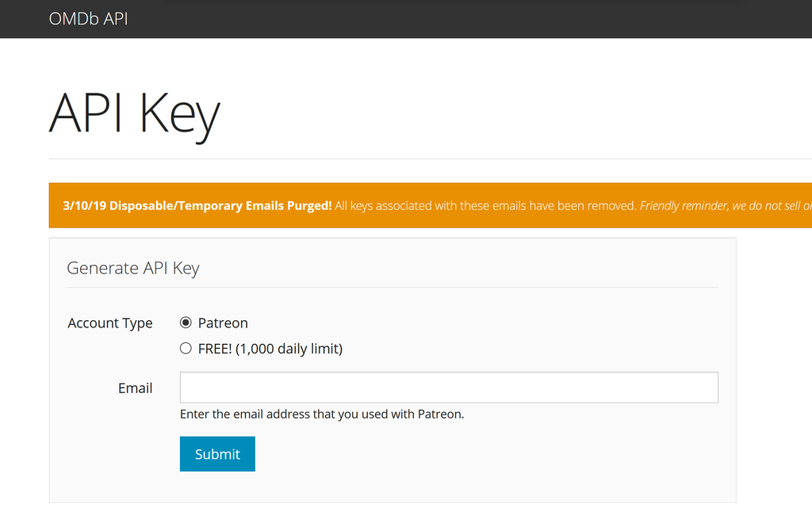

```python
Image(filename='Captura9.png')
```

En la página se encuentra una explicación de cómo usar la API

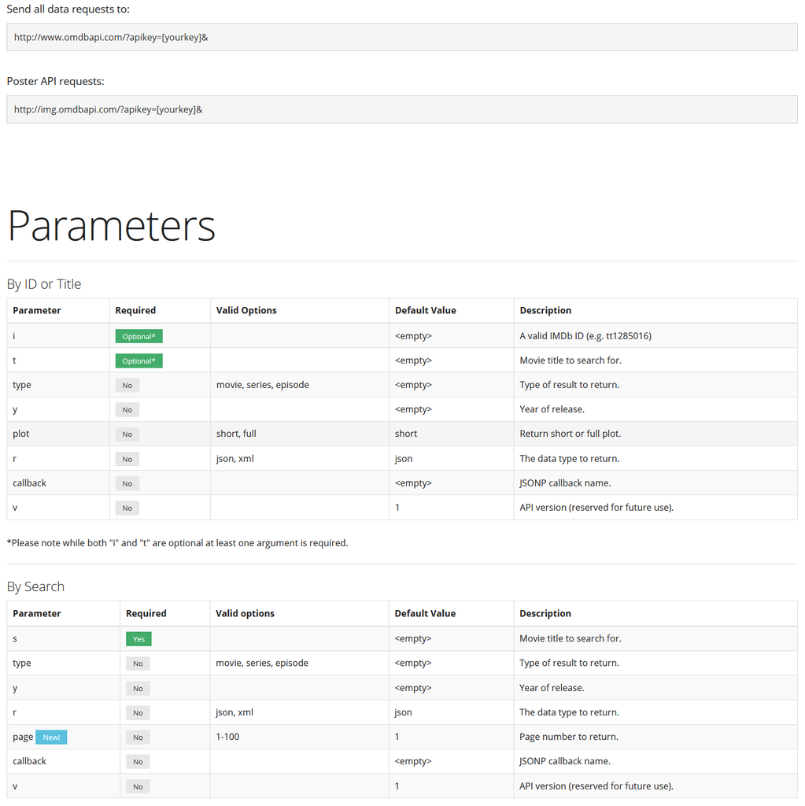

```python
Image(filename='Captura10.png')
```

Se va crear un ejemplo para recuperar información de la película "Guardians of the Galaxy". Se usa el parámetro s que representa el título de la película y el parámero type para indicar que es una película.

```python
import urllib.request
from urllib.parse import urlencode, quote_plus
clave="7495bc94"
uri="http://www.omdbapi.com/?apikey="+clave
url = uri + "&"+urlencode({"s":"Guardians of the Galaxy", "type":"movie"},quote_via=quote_plus)
manf = urllib.request.urlopen(url)
for line in manf:
    print(line.decode().strip())
```

```
{"Search":[{"Title":"Guardians of the Galaxy","Year":"2014","imdbID":"tt2015381","Type":"movie","Poster":"https://m.media-amazon.com/images/M/MV5BMTAwMjU5OTgxNjZeQTJeQWpwZ15BbWU4MDUxNDYxODEx._V1_SX300.jpg"},{"Title":"Guardians of the Galaxy Vol. 2","Year":"2017","imdbID":"tt3896198","Type":"movie","…
```

Ahora se puede tomar el identificador(campo imdbID) de la película para obtener más información de la misma.

```python
import urllib.request
from urllib.parse import urlencode, quote_plus
clave="7495bc94"
uri="http://www.omdbapi.com/?apikey="+clave
url = uri + "&"+urlencode({"i":"tt3896198"},quote_via=quote_plus)
manf = urllib.request.urlopen(url)
for line in manf:
    print(line.decode().strip())
```

[output not shown]